# Betting on the Economy: A Comparative Analysis of Sports Gambling and Household Consumption Patterns

Camden Hughes

29 April 2025

# Introduction

This code through explores the relationship between sports betting consumption. household consumption trends, and economic sentiment, aiming to determine whether consumers treat spending on betting platforms similarly to essential household expenditures and adjust their spending to match their current outlook of the economy’s performance. By analyzing available financial and behavioral data, this project investigates the potential economic and psychological connections between traditional consumption and the rising normalization of sports betting.

## Content Overview

Specifically, we’ll explain and demonstrate how spending patterns on popular sports betting platforms like FanDuel, BetMGM, ESPNBet and PrizePicks compare to household personal consumption expenditures. We’ll also incorporate consumer sentiment data to explore whether changes in economic optimism correlate with betting behavior. We will be using public data sources such as the Federal Reserve Bank of St. Louis (FRED) database, as well as public data collected by the Colorado Department of Revenue reporting betting proceeds each month in the state of Colorado, all of which has been manually compiled into one convenient dataset called “coloradosb.” A visualization will help map and interpret these relationships over time.

## Why You Should Care

This topic is valuable because the rapid rise of sports betting raises important questions about consumer behavior, financial vulnerability, and regulatory oversight. Understanding whether sports betting follows similar trends to household consumption can shed light on whether this industry capitalizes on economic stress or mirrors legitimate spending behavior—insights that are crucial for policymakers, financial educators, and the public as sports betting becomes increasingly embedded in everyday life.

## Packages

We will use the following packages for the vignette.

```r
library(pander)
library(kableExtra)
```

## Learning Objectives

Specifically, you’ll learn how to collect data, create viable data sets, and utilize these data sets to create visualizations using base R functions.

# Data Dictionary

observation_date: observation date (previous month)  
UMCSENT: consumer sentiment INDEXED  
PCE: personal consumption expenditure (in billions)  
SBPROCEED: sports betting proceeds in Colorado (dollar amount)  
PCEINDEX: personal consumption expenditures INDEXED ((pce/1000)4)  
SBINDEX: sborts betting proceeds INDEXED ((sbproceed/10000000)2)

The first step after running the data is to convert the variables to the proper format (which will later simplify the graphing process)–for example, converting the observation date from character to date format so it can be used interactively as the x-axis measurement later on. It is also important to run the summaries of each variable in order to gain an idea of the range of data to accommodate when creating a graph.

```r
class(df)                                                          #Reading classification of data set
```

```
## [1] "function"
```

```r
csb <- read.csv("https://raw.githubusercontent.com/chughgsu/hughes/main/coloradosb.csv",
                stringsAsFactors = FALSE)
csb$observation_date <- as.Date(csb$observation_date,
                                format = "%m/%d/%Y")    #Converting observation date format from character to date format

summary(csb$UMCSENT)
```

```
##    Min. 1st Qu.  Median    Mean 3rd Qu.    Max.
##   50.00   63.75   69.40   69.53   76.85   88.30
```

```r
summary(csb$PCEINDEX)
```

```
##    Min. 1st Qu.  Median    Mean 3rd Qu.    Max.
##   57.82   66.34   72.38   71.54   77.20   81.76
```

```r
summary(csb$SBPINDEX)
```

```
##    Min. 1st Qu.  Median    Mean 3rd Qu.    Max.
##   25.73   59.11   85.02   83.61  106.36  143.29
```

## Advanced Examples

This chunk of R code creates a custom line graph that visualizes the relationship between three variables over time: consumer sentiment (UMCSENT), personal consumption expenditures (PCEINDEX), and sports betting proceeds (SBPINDEX). The code first defines the plotting area, setting the x-axis to span the range of dates in the dataset and the y-axis to accommodate values from 0 to 150. It then customizes the x-axis by labeling it with monthly date intervals and adjusting the label positioning and font size for clarity. Titles are added for both the x-axis and the entire graph to provide context.

Next, the code plots the three data series as colored lines—blue for consumer sentiment, pink for personal consumption, and green for sports betting proceeds—allowing for a clear visual comparison of trends over time. It finishes by manually creating a legend using colored segments and corresponding text labels positioned at the top of the graph. This custom legend ensures that viewers can distinguish between the three variables without relying on default legend placement, enhancing the graph’s readability and interpretability.

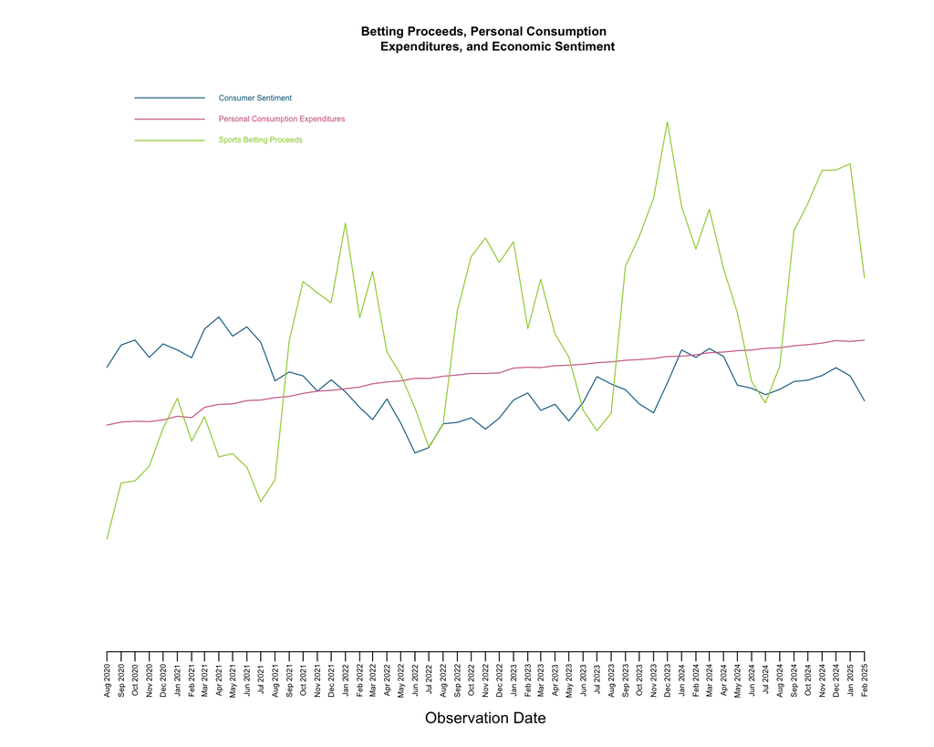

```r
#Creating graph dimensions/axes

plot.new()
plot.window(
  xlim = range(csb$observation_date, na.rm = TRUE),
  ylim = c(0, 150))
par(las = 2)                                                    # Axis labels vertical
axis(side = 1,                                                  # Add x-axis
     at = seq(from = min(csb$observation_date),
              to = max(csb$observation_date), by = "months"),   # Axis range as dates
     labels = format(seq(from = min(csb$observation_date),
                         to = max(csb$observation_date),
                         by = "months"), "%b %Y"),              # Labels formatted as dates
     lwd = 1,                                                   # Line width
     hadj = 0.8,                                                # Horizontal label position
     padj = 0.5,
     cex.axis = 0.5)                                            # Axis label ticks font size
title( xlab="Observation Date" )                                # Axis labels
title( main="Betting Proceeds, Personal Consumption
       Expenditures, and Economic Sentiment",
       cex.main=0.8)                                            # Graph title



#Adding plot lines

x<-csb$observation_date
y1<-csb$UMCSENT
y2<-csb$PCEINDEX
y3<-csb$SBPINDEX                                                # Assignment for easy plotting

lines(x, y1, col="deepskyblue4")                                # Consumer sentiment trend line
lines(x, y2, col="hotpink3")                                    # Personal consumption trend line
lines(x, y3, col="yellowgreen")                                 # Sports betting proceeds trend line

#Adding legend lines

segments(x0 = as.Date("2020-10-01"), y0 = 150,
         x1 = as.Date("2021-03-01"), y1 = 150,
         col="deepskyblue4")                                    # Legend lines
text(as.Date("2021-04-01"), 150, ("Consumer Sentiment"),
     cex=0.5, adj=0, col="deepskyblue4")                        # Legend text
segments(x0 = as.Date("2020-10-01"), y0 = 144,
         x1 = as.Date("2021-03-01"), y1 = 144,
         col="hotpink3")
text(as.Date("2021-04-01"), 144, ("Personal Consumption Expenditures"),
     cex=0.5, adj=0, col="hotpink3")
segments(x0 = as.Date("2020-10-01"), y0 = 138,
         x1 = as.Date("2021-03-01"), y1 = 138,
         col="yellowgreen")
text(as.Date("2021-04-01"), 138, ("Sports Betting Proceeds"),
     cex=0.5, adj=0, col="yellowgreen")
```

# Observations

The fluctuation of monthly sports betting proceeds supports the hypothesis that sports betting consumption is highly elastic, which implies that there is a *possibility* that economic sentiment determines how much consumers spend on sports betting. However, the varying timing of multiple popular sports for specific months of each year is a very evident reason behind the majority of changes in spending; for example, there has been an average increase of over 250 million dollars in sports betting revenue from August to January each year for the past five years, all of which can be attributed to professional and college football. It is impossible to tell using this study how much consumer sentiment has an impact on these seasonal fluctuations. In fact, there is a high likelihood that, considering the data, sports betting consumption is elastic to the time of year (selection of goods offered, per se) and not predictions of the economy’s performance.

# Works Cited

This code through references and cites the following sources:

- Colorado Department of Revenue, Specialized Business Group (2025). [Sports Betting Monthly Reports](https://sbg.colorado.gov/sports-betting-monthly-reports)
- Federal Reserve Bank of St. Louis (2025). [University of Michigan: Consumer Sentiment](https://fred.stlouisfed.org/series/UMCSENT)
- Federal Reserve Bank of St. Louis (2025). [Personal Consumption Expenditures](https://fred.stlouisfed.org/series/PCE)

## Additional Resources

Learn more about this code-through with the following:

- Resource I: [Big Betting Data Document by Camden Hughes](https://studentgsu-my.sharepoint.com/:x:/g/personal/chughes31_student_gsu_edu/EaZ-WsiXRsZDp_FFxvjlYlYBdY6YMS6lRMw958vLFD4hUw?e=fZzpsD)
- Resource II: [Colorado Sports Betting Data](https://sbg.colorado.gov/sports-betting-monthly-reports)
- Resource III: [Data Graphics: Customizing Plots](https://ds4ps.org/dp4ss-textbook/p-062-customized-graphics.html)